# Intermediate Python slides

# Exercise Break:

1. Write a function that finds the max of 3 numbers in a list
2. Write a function that will multiply all the numbers in a list
3. Write a program to reverse a string ( hint: `help('str')` )
4. Write a function that takes in a number as a parameter and checks whether it is prime or not

## Classes

#### The workhose of object oriented programming.

- They provide a means for bundling data and functionality together. Creating a new class creates a new *type* of objects
- Each class instance can have attributes attached to them for maintaining the state of the *instance*

```
class ClassName:
    #statement 1
    #statement 2
```

### Scope and Namespace:

A *namespace* is a mapping from names to objects.

```
* currently implemented as Python dictionaries,
```

Examples:

- the set of built-in names (containing functions such as abs(), and built-in exception names)
- the global names in a module;
- the local names in a function invocation.

The important thing to know about namespaces is that *there is absolutely no relation between names in different namespaces*

### Scope is the textual region of a program where a namespace is accessible

```python
def scope_test():
    def do_local():
        spam = "local spam"

    def do_nonlocal():
        nonlocal spam
        spam = "nonlocal spam"

    def do_global():
        global spam
        spam = "global spam"

    spam = "test spam"
    do_local()
    print("After local assignment:", spam)
    do_nonlocal()
    print("After nonlocal assignment:", spam)
    do_global()
    print("After global assignment:", spam)

scope_test()
print("In global scope:", spam)
```

```
After local assignment: test spam
After nonlocal assignment: nonlocal spam
After global assignment: nonlocal spam
In global scope: global spam
```

[figure not shown]

```python
Image("../src/photos/spam.png")
```

#### Back to Classes:

Class objects can do two operations;

1. arrtribute references `MyClass.i`
2. Instantiations `x = MyClass()`

```python
class MyClass:
    "A Simple Example of a class"
    i = 12345

    def f(self):
        return 'hello world from internal method'
```

```python
x = MyClass()
x.f()
```

```
'hello world from internal method'
```

### `__init()`

If a class defined a `__init__` method on the class, when instantiated, the `__init__` is automatically invoked

```python
class Dog():
    def __init__(self, enter_breed):
        self.breed = enter_breed

sam = Dog(enter_breed='Lab')
frank = Dog(enter_breed='Huskie')
```

```python
sam.breed
```

```
'Lab'
```

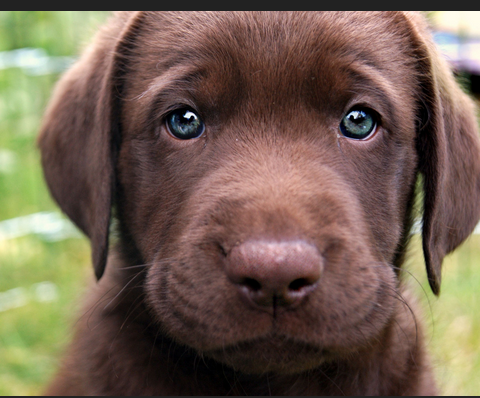

```python
Image("../src/photos/labador.png")
```

```python
class Dog():
    def __init__(self, enter_breed,enter_name):
        self.breed = enter_breed
        self.name = enter_name

sam = Dog(enter_breed='Lab', enter_name='Sam')
frank = Dog(enter_breed='Huskie',enter_name='Frank')

sam.name
```

```
'Sam'
```

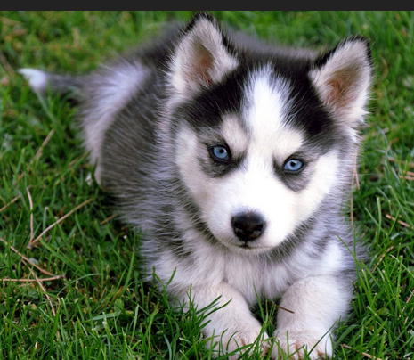

```python
Image("../src/photos/huskie.png")
```

### Methods

Methods are functions that are define under the classes scope

```python
class Circle():
    pi = 3.14

    #circle gets initiated with a radius
    def __init__(self, enter_radius=1):
        self.radius= enter_radius

    # Area method will calculate the area
    def area(self):
        return Circle.pi * self.radius ** 2

    # Method for resetting Radius
    def setRadius(self, raduis1):
        self.radius = raduis1

    # getting the radius
    def getRadius(self):
        return self.radius
```

```python
c = Circle(enter_radius=3)
```

```python
c.area()
```

```
28.26
```

```python
c.setRadius(2)
c.area()
```

```
12.56
```

### Inheritance:

One class, helping out another

```python
class Animal():
    def __init__(self):
        print("Animal created")

    def whoAmI(self):
        print("Animal")
    def eat(self):
        print("eating")
```

```python
class Dog(Animal):
    def __init__(self):
        Animal.__init__(self)
        print("Dog Created")
    def whoAmI(self):
        print("Dog")
    def bark(self):
        print("woof")
```

### Extending and Overriding:

- Base classes help form derived classes
- derived classes extend or overide the functionality of ancestors

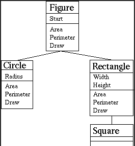

```python
Image("../src/photos/extening_overriding_oop.png")
```

### Extending and Overriding:

```python
d = Dog()
```

```
Animal created
Dog Created
```

#### An Example of a modifed behavior

```python
d.whoAmI()
```

```
Dog
```

#### An example of an Inherited funtion

```python
d.eat()
```

```
eating
```

#### Extend base class by adding `bark()`

```python
d.bark()
```

```
woof
```

### Making a Checking Account quick

Defining a class that can perform simple accounting for us

```
class Customer():
    """
    A customer of ABC Bank with a checking account. Customers have the
    following properties:

    Attributes:
        name: A string representing the customer's name.
        balance: A float tracking the current balance of the customer's account.
    """
```

### Start with your instantiated variables

```
def __init__(self, name, balance=0.0):
        """
        Return a Customer object whose name is *name* and starting
        balance is *balance*.
        """
        self.name = name
        self.balance = balance
```

### Define your first method for holding balances

```
def available_balance(self):
        """
        Return the available balance
        """
        return self.balance
```

### Define the method to `withdraw` funds

```
def withdraw(self, amount):
        """
        Return the balance remaining after withdrawing *amount*
        dollars.
        """
        if amount > self.balance:
            print('Amount greater than available balance.')
        else:
            self.balance -= amount
            return self.balance
```

### Define your `deposit` method

```
def deposit(self, amount):
        """
        Return the balance remaining after depositing *amount*
        dollars.
        """
        self.balance += amount
        return self.balance
```

```python
class Customer():
    """
    A customer of ABC Bank with a checking account.
    Attributes:
        name: A string representing the customer's name.
        balance: A float tracking the current balance of the customer's account.
    """

    def __init__(self, name, balance=0.0):
        """
        Return a Customer object whose name is *name* and starting
        balance is *balance*.
        """
        self.name = name
        self.balance = balance

    def available_balance(self):
        """
        Return the available balance
        """
        return self.balance

    def withdraw(self, amount):
        """
        Return the balance remaining after withdrawing *amount*
        """
        if amount > self.balance:
            print('Amount greater than available balance.')
        else:
            self.balance -= amount
            return self.balance

    def deposit(self, amount):
        """
        Return the balance remaining after depositing *amount*
        """
        self.balance += amount
        return self.balance
```

### Testing the Class

```python
c = Customer("tom", 100)
```

```python
c.withdraw(50)
c.available_balance()
```

```
50
```